# Usehotkeys

GuohuanZhang

2022/8/25

## R Markdown

This is the 4th R Markdown document of GuohuanZhang.

### This R Markdown document aims to show how to use hotkeys

### Find more at https://github.com/Thuoyuing/Thuoyuing.github.io

# 今天主要展示包括管道符在内的一系列带%的操作符的功能

# 以及如何设置它们的快捷建，从而更方便地书写代码

### 参考资料：https://github.com/r-stata/hotkeys

[figure not shown]

# 首先载入需要用到的包

```r
if(!require(pacman)){
  install.packages("pacman")
}
```

```r
pacman::p_load(tidyverse,  # 书写整洁的代码
               magrittr,   # 包含更多管道符——%<>%
               imager,     # 读取文件夹中的图片
               devtools    # 从github上下载包
)
```

# 1、向右操作符

### 向右操作符在Use Pipe Operator 中已经详细展示过了

https://thuoyuing.github.io/PipeOperator.html

```r
a <-  c(1,10,100,1000,10000)
a %>% .[2:4]
```

```
## [1]   10  100 1000
```

```r
a %>% mean()
```

```
## [1] 2222.2
```

# 2、以及复合赋值操作符

```r
a
```

```
## [1]     1    10   100  1000 10000
```

```r
a %<>% log10()
a
```

```
## [1] 0 1 2 3 4
```

a 经过log10操作后，又传回赋值给a

# 3、值匹配操作符

```r
(1:10) %in% c(3,7,12)
```

```
##  [1] FALSE FALSE  TRUE FALSE FALSE FALSE  TRUE FALSE FALSE FALSE
```

从1到10，只有3和7可以与右边的c(3,7,12)匹配，因此3和7是TURE，其他的则是FALSE

### 更直观一点的应用场景：

```r
tibble(id = 1:1000,
       race = sample(c("汉族","布依族","回族","仡佬族","畲族",
                       "朝鲜族","维吾尔族","苗族","哈尼族","傣族"),1000,replace = T),
       SystolicP = rnorm(1000,125,sd=10)) -> df
df
```

```
## # A tibble: 1,000 x 3
##       id race   SystolicP
##    <int> <chr>      <dbl>
##  1     1 畲族        140.
##  2     2 苗族        132.
##  3     3 朝鲜族      141.
##  4     4 汉族        115.
##  5     5 仡佬族      119.
##  6     6 苗族        126.
##  7     7 仡佬族      123.
##  8     8 汉族        133.
##  9     9 畲族        123.
## 10    10 回族        120.
## # ... with 990 more rows
```

1000个人的民族和收缩压

```r
df %>% dplyr::filter(race %in% c("汉族","布依族","苗族"))
```

```
## # A tibble: 302 x 3
##       id race   SystolicP
##    <int> <chr>      <dbl>
##  1     2 苗族        132.
##  2     4 汉族        115.
##  3     6 苗族        126.
##  4     8 汉族        133.
##  5    12 汉族        136.
##  6    17 布依族      137.
##  7    18 苗族        125.
##  8    32 汉族        125.
##  9    36 苗族        151.
## 10    37 汉族        123.
## # ... with 292 more rows
```

这样可以选出汉族、布依族、苗族的样本

后续也可以按民族分组汇总，例如计算均值：

```r
df %>%
  dplyr::filter(race %in% c("汉族","布依族","苗族")) %>%
  group_by(race) %>%
  summarise(SystolicP = mean(SystolicP))
```

```
## # A tibble: 3 x 2
##   race   SystolicP
##   <chr>      <dbl>
## 1 布依族      125.
## 2 汉族        124.
## 3 苗族        126.
```

# 4、解释操作符

### 作用：把左侧数据的属性名传给右侧，让右侧的调用函数直接通过名字，就可以获取左侧的数据

比如：这样是不可以的

```r
df %>% .[which(SystolicP>135),]
```

```
## Error in which(SystolicP > 135): 找不到对象'SystolicP'
```

不能获取df的变量名 “SystolicP”

但是用解释操作符就可以

```r
df  %$%  .[which(SystolicP>135),]
```

```
## # A tibble: 161 x 3
##       id race   SystolicP
##    <int> <chr>      <dbl>
##  1     1 畲族        140.
##  2     3 朝鲜族      141.
##  3    12 汉族        136.
##  4    14 哈尼族      142.
##  5    17 布依族      137.
##  6    36 苗族        151.
##  7    46 布依族      138.
##  8    57 仡佬族      136.
##  9    59 回族        143.
## 10    65 朝鲜族      140.
## # ... with 151 more rows
```

# 5、矩阵乘法

```r
x <- matrix(1:4,nrow = 2)
x
```

```
##      [,1] [,2]
## [1,]    1    3
## [2,]    2    4
```

```r
x %*% x
```

```
##      [,1] [,2]
## [1,]    7   15
## [2,]   10   22
```

# 6、整除

```r
10 %/% 4
```

```
## [1] 2
```

# 7、取余

```r
10%%3
```

```
## [1] 1
```

正确使用这些操作符是非常方便的，不方便的点在于这些符号不太好敲出来

# 不过我们可以设置快捷键

# 下面我们用hotkeys包自定义这些操作符的快捷建：

## 需要先下载hotkeys包

```r
devtools::install_github("r-stata/hotkeys")
```

## 然后按照下图方式操作

#### 第一步

[figure not shown]

#### 第二步

可以按照自己的习惯设置

我喜欢把快捷键和符号的内容关联起来

比如：

向右操作符就使用ctrl+alt+右方向键

匹配符 %in% 因为有 in, 所以我用ctrl+alt+i

矩阵乘法%*%，而星号和8是一个按键，所以我用ctrl+alt+8。等等……

甚至还可以定义左右赋值号

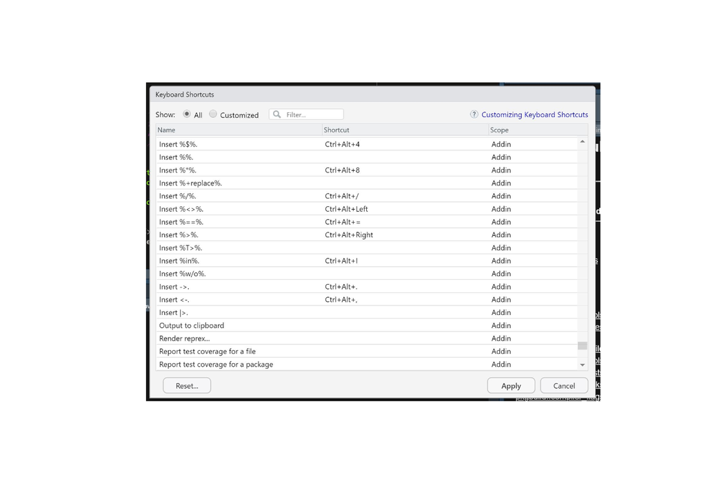